# HW_1_1_Основи_статистики

В цьому домашньому завданні відпрацюємо з вами знання, отримані в модулі зі статистики.

**Завдання 1.** Ми обговорили з Вами на лекції, що велика літера Сігма грецького алфавіту позначає в математиці суму. Знайдіть з використанням Python $\Sigma x$, $\Sigma x^2$, та $\Sigma (x-1)^2$ для наступного набору даних: `1 3 4` Виведіть результат кожного обчислення на екран.

обчислення суми *x*

```python
result = 0
list_0 = [1, 3, 4]
for x in list_0:
    result += x

print(result)
```

```
8
```

обчислення суми *x^2*

```python
result = 0
list_1 = [1, 3, 4]
for x in list_1:
    result += x**2

print(result)
```

```
26
```

обчислення суми *(x-1)^2*

```python
result = 0
list_2 = [1, 3, 4]
for x in list_2:
    result += (x - 1)**2

print(result)
```

```
13
```

**Завдання 2.** Ми зібрали дані про суму покупок в гривнях 20ма випадково обраними клієнтами в нашому магазині (всього клієнтів у нас більше) за минулий місяць. Вони представлені в змінній `sum_purchases`. Знайдіть **вибіркове середнє** для цих даних кожним з зазначених методів:

2.1. без використання жодних бібліотек, користуючись тільки Python.  
2.2. використовуючи відповідний метод бібліотеки `numpy`.

Виведіть результат обчислень в кожному з випадків на екран та порівняйте результати. Вони співпадають?

```python
sum_purchases = [ 316,  493,  367,  153,  224,  121,  322,  450,  196,  397,  281,
  239,  484,  124,  223,  448,  432,  255, 4310, 3524]
```

```python
length = len(sum_purchases)
mean_x = sum(sum_purchases)/length
print(f"вибіркове середнє без використання бібліотек: {mean_x}")
```

```
вибіркове середнє без використання бібліотек: 667.95
```

```python
import numpy as np

print("вибіркове середнє використовуючи numpy: ", np.mean(sum_purchases))
```

[output not shown]

розраховні значення в обох випадках співпадають

**Завдання 3.** Для того ж набору даних в змінній `sum_purchases` обчисліть **медіану** кожним з зазначених методів:

3.1. без використання жодних бібліотек, користуючись тільки Python.  
3.2. використовуючи відповідний метод бібліотеки numpy.

Виведіть результат обчислень в кожному з випадків на екран. Порівняйте результати зі значенням вибіркового середнього. Напишіть коментар, для яких задач ви б використовували вибіркове середнє, а для яких - медіану?

```python
print(sum_purchases)
print(type(list))
sorted_purchases = sorted(sum_purchases)
print("Відсортований список:", sorted_purchases)

mid_1 = len(sorted_purchases) // 2 - 1
mid_2 = len(sorted_purchases) // 2

mediana = (sorted_purchases[mid_1] + sorted_purchases[mid_2]) / 2
print(f"медіана без використання бібліотек: {mediana}")
```

[output not shown]

```python
import numpy as np

print("медіана використовуючи numpy: ", np.median(sum_purchases))
```

```
медіана використовуючи numpy:  319.0
```

розраховні значення в обох випадках співпадають

Вибіркове середнє краще використовувати, коли дані нормально розподілені. Воно дає точне середнє значення для таких випадків.

Медіану краще використовувати, коли маємо справу з асиметричним розподілом.

**Завдання 4**. Обчислість стандартне відхилення наведеної вибірки в змінній `sum_purchases` кожним з зазначених методів:

4.1. без використання жодних бібліотек, користуючись тільки Python.  
4.2. використовуючи відповідний метод бібліотеки numpy.

Виведіть результат обчислень в кожному з випадків на екран.

```python
sum_minus_mean = [(el - mean_x)**2 for el in sum_purchases]
var_x_general = sum(sum_minus_mean)/(len(sum_purchases)-1)
print(f"стандартне відхилення  без використання бібліотек: {var_x_general}")
```

[output not shown]

```python
import numpy as np

print("стандартне відхилення   використовуючи numpy: ", np.var(sum_purchases, ddof=1))
```

[output not shown]

розраховні значення в обох випадках співпадають

**Завдання 5**. Ми провели дослідження віку студентів-першокурсників. Виявилось, що

- 10 студентів мають вік 16 років
- 25 студентів - 17 років
- 20 студентів - 18 років
- 2 студенти - 20 років

Обчислість середнє значення для цієї вибірки будь-яким способом - на чистому Python або з numpy - та виведіть результат на екран.

```python
h_list = []
i, j, t = 0, 0, 0
while(i < 10):
    h_list.append(16)
    i += 1
while(j < 25):
    h_list.append(17)
    j += 1
while(t < 20):
    h_list.append(18)
    t += 1
h_list.append(20)
h_list.append(20)
print(h_list)
mid_h = sum(h_list)/len(h_list)
print(mid_h)
```

```
[16, 16, 16, 16, 16, 16, 16, 16, 16, 16, 17, 17, 17, 17, 17, 17, 17, 17, 17, 17, 17, 17, 17, 17, 17, 17, 17, 17, 17, 17, 17, 17, 17, 17, 17, 18, 18, 18, 18, 18, 18, 18, 18, 18, 18, 18, 18, 18, 18, 18, 18, 18, 18, 18, 18, 20, 20]
17.280701754385966
```

як варіант можна порахувати без створення списку:

```python
h_sum = 10*16 + 25*17 + 20*18 + 40
amount = 10 + 25 + 20 + 2
print(h_sum/amount)
```

```
17.280701754385966
```

**Завдання 6**. Крім даних про суму покупок, ми зібрали ще дані про кількість відвідувань кожного з кожного покупця, які знаходяться в змінній `visits`. Обчисліть коефіцієнт кореляції Пірсона для суми покупок і кількості відвідувань кожним з зазначених методів:

6.1. без використання жодних бібліотек, користуючись тільки Python.  
6.2. використовуючи відповідний метод бібліотеки numpy.

Виведіть результат на екран. Проаналізуйте результат.

Виведіть додатково графік розсіювання викликавши код нижче і зробіть заключення, чи варто щось змінити при підрахунку кореляції, аби коефіцієнт Пірсона показував коректну оцінку лінійної залежності?

```python
visits = [ 6,  2, 10,  3,  9,  9,  2,  3,  6,  6, 10,  2,  5, 10,  3,  5,  4,
        7,  4,  2]
```

```python
std_s_sample = np.sqrt(sum(sum_minus_mean)/(len(sum_purchases)-1))
mean_y = sum(visits)/len(visits)
v_minus_mean = [(el - mean_y)**2 for el in visits]
std_v_sample = np.sqrt(sum(v_minus_mean)/(len(visits)-1))

xy = [ (sum_purchases[i] - mean_x)*(visits[i] - mean_y) for i in range(len(sum_purchases))]

cov_xy = sum(xy)/(len(sum_purchases)-1)
p_cor = cov_xy / (std_s_sample * std_v_sample)

print(f"кореляція Пірсона  без використання бібліотек: {p_cor}")
```

```
кореляція Пірсона  без використання бібліотек: -0.3026584468766646
```

```python
np.corrcoef(sum_purchases, visits)
```

```
array([[ 1.        , -0.30265845],
       [-0.30265845,  1.        ]])
```

Значення -0.3026 вказує на слабку негативну кореляцію між двома змінними. Це означає, що є певна тенденція, при якій одна змінна зменшується, коли інша зростає, але цей зв'язок є досить слабким.

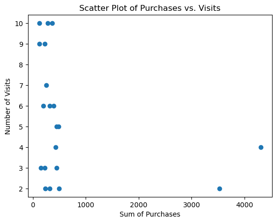

```python
import matplotlib.pyplot as plt

plt.scatter(sum_purchases, visits)
plt.title('Scatter Plot of Purchases vs. Visits')
plt.xlabel('Sum of Purchases')
plt.ylabel('Number of Visits');
```

потрібно очистити дані від викидів аби коефіцієнт Пірсона показував коректну оцінку лінійної залежності

**Завдання 7**. В попередньому завданні ми помітили, що викиди нам заважають отримати "правдиве" значення кореляції. Давайте вилучимо записи, які відповідають значенням з викидами в сумі покупок і обчисліть коеф. кореляції. Для цього поставте `threshold`, який дорінює середньому значенню + 2 стандартних вдіхилля суми покупок і всі значення, які більше за нього, будемо вважати викидами (є і інші правила для визначення викидів - з ним и познайомимось пізніше).

Вилучіть значення з обох масивів і обчисліть коеф. кореляції Пірсона з допомогою `numpy` для кількості візитів і суми покупок без записів-викидів. Виведіть результат на екран, побудуйте діаграму розсіювання і проаналізуйте результат: що можемо сказати про залежність в даних?